# 2026 Spring BIO 2100 Final Creation and Answers

33 points

## Instructions! Read this first.

The exam is open note, open course website, open class-related code repositories (mine and those you produced in class). However, you may not get external help ( from other students, AI, directed internet searches, etc.). Please update the statement below to acknowledge these instructions (and that you can use git).

I, INSERT YOUR NAME HERE, promise to not seek external help on the exam. I understand any academic issues will result in a D or F on the exam or in the class and be reported to the Dean of Students. Infractions will also result in me being unable to obtain a letter of recommendation from the department for professional school applications.

The exam should be committed and pushed to github by Monday, 5/18/2026, at 10:00 AM. You can also commit and push along the way, but please mark your final commit (when you are finished) with the comment **Finished - ready to grade!.**

For all questions, the statement is based on what you might hear from a colleague (e.g., “How do I analyze this?”). This is like when you get a call to review a paper. Please answer questions succinctly but with necessary details on all required steps/concerns you might need to consider.

While the exam is based on a realistic scenario (with citations), some data and scenarios are fictional and contrived for the exam (i.e., don’t quote all this as fact!).

Good luck!

## Background

Community science is a growing area where people who are not traditionally considered scientists assist with research projects. This can include providing data, assisting with project implementation, and analyzing data (Gosnell 2023). Community scientists can expand data collection efforts beyond what a single lab can accomplish and greatly enrich projects.

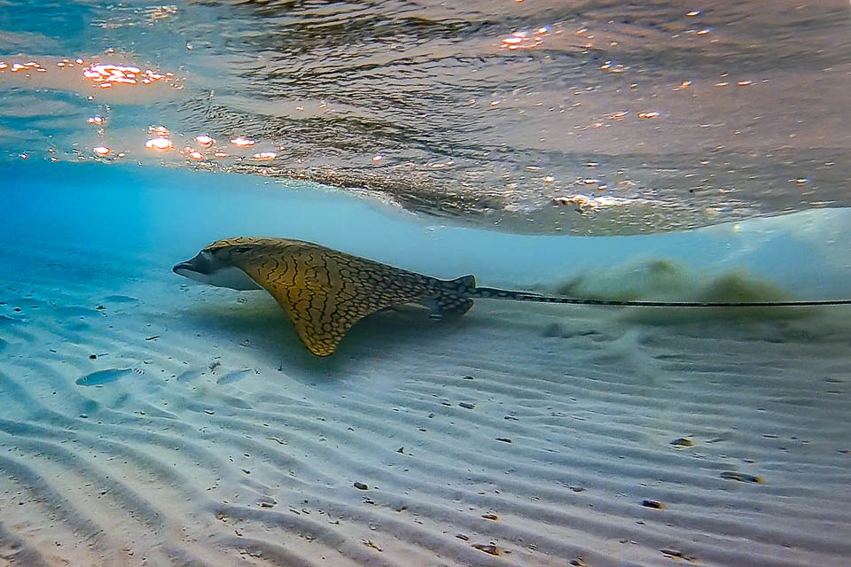

Photo of a rarely seen Ornate eagle ray (Aetomylaeus vespertilio), taken at Landaa Giraavaru, Baa Atoll, Maldives (February 2018). SunnyMart, CC BY-SA 4.0 <https://creativecommons.org/licenses/by-sa/4.0>, via Wikimedia Commons

## 1

Previous research indicated eagle rays are nocturnal feeders, with 80% of their feeding activity occurring at night. The collected images included 76 shots of rays feeding, with 50 of those shot in daylight hours. Does this match expectations?

Make sure you include (6 points)

- null hypothesis (1 point)
  - The proportion of eagle ray feeding activity during daylight is 20%.
- alternative hypothesis (1 point)
  - The proportion of eagle ray feeding activity during daylight is not 20%.
- explanation for test you will use (1.5 point)
- I have two outcomes that I am comparing to a set proportion of success, so I will use a binomal test.
- results from statistical test (1 point)

```r
binom.test(50, 76, p = 0.20, alternative = "two.sided")
```

```
    Exact binomial test

data:  50 and 76
number of successes = 50, number of trials = 76, p-value < 2.2e-16
alternative hypothesis: true probability of success is not equal to 0.2
95 percent confidence interval:
 0.5401240 0.7629432
sample estimates:
probability of success
             0.6578947
```

or

```r
binom.test(76-50, 76, p = 0.80, alternative = "two.sided")
```

```
    Exact binomial test

data:  76 - 50 and 76
number of successes = 26, number of trials = 76, p-value < 2.2e-16
alternative hypothesis: true probability of success is not equal to 0.8
95 percent confidence interval:
 0.2370568 0.4598760
sample estimates:
probability of success
             0.3421053
```

- clear explanation of how results relate to your stated hypotheses (1.5 point)
  - since p<.001(<.05), I reject my null hypothesis. There is evidence that the proportion of rays feeding during the day is not 20%.

## 2

Scientists used imaging tools to gather extra information from the the images. Note different images provided different pieces of data due to the perspective. For example, they were able to use some pictures to determine both sex (male, female, unknown) and wing width for each individual. Data is available at

```r
ray_data <- read.csv("ray_data.csv", stringsAsFactors = T)
```

Use the data to determine if wing width differs among sexes. Make sure you include (6 points)

- null hypothesis (1 point)
- H<sub>0</sub>: Wing width does not differ among sexes (i.e., $\mu_{male}=\mu_{female}=\mu_{unknown}$)
- alternative hypothesis (1 point)
- H<sub>A</sub>: Wing width does differ among sexes (i.e., at least one $\mu_\text{one measured group}\neq\mu_\text{other measured group}$)
- explanation for test you will use (1.5 point)
- I will use an ANOVA, a type of linear model, since I am comparing means among groups
- results from statistical test (1 point)

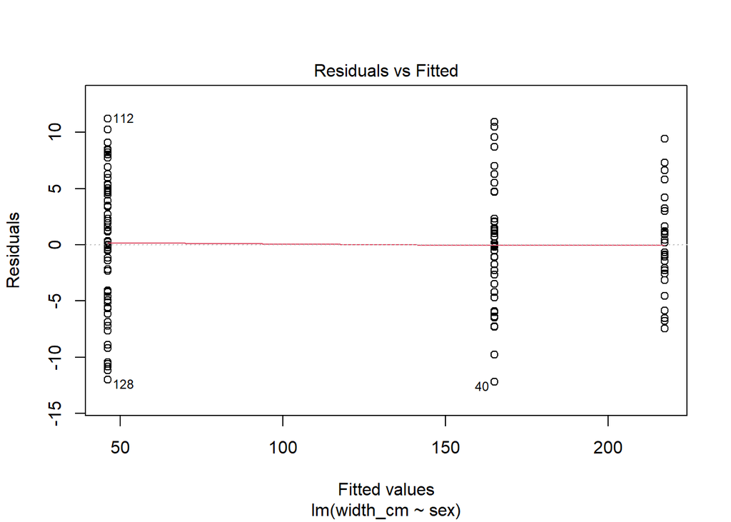

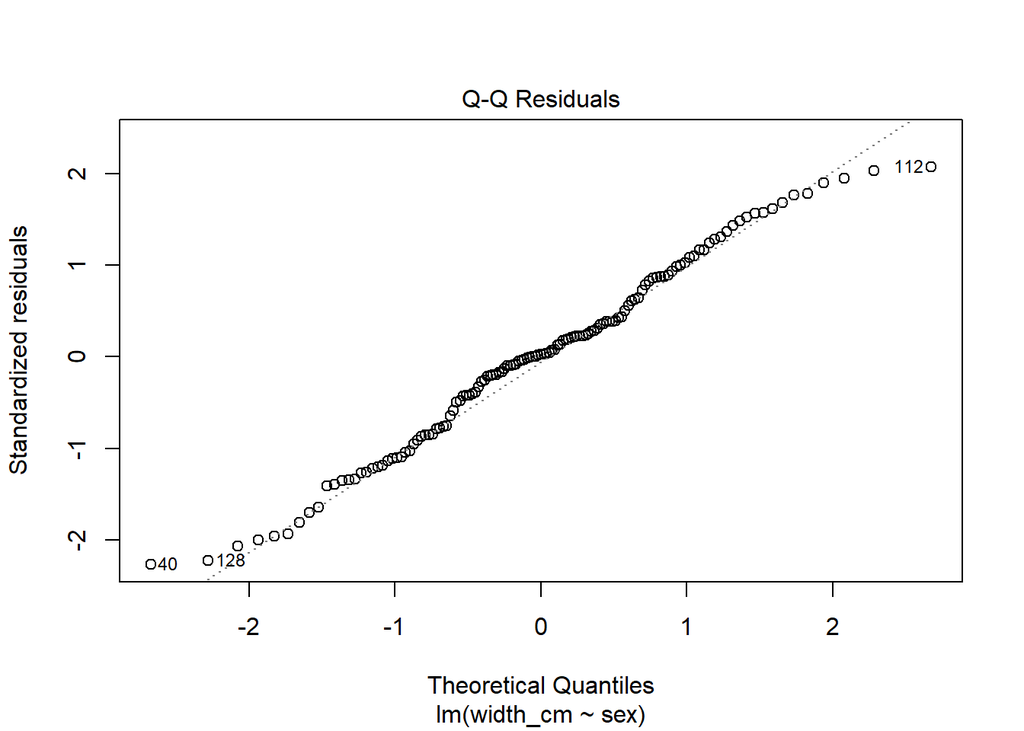

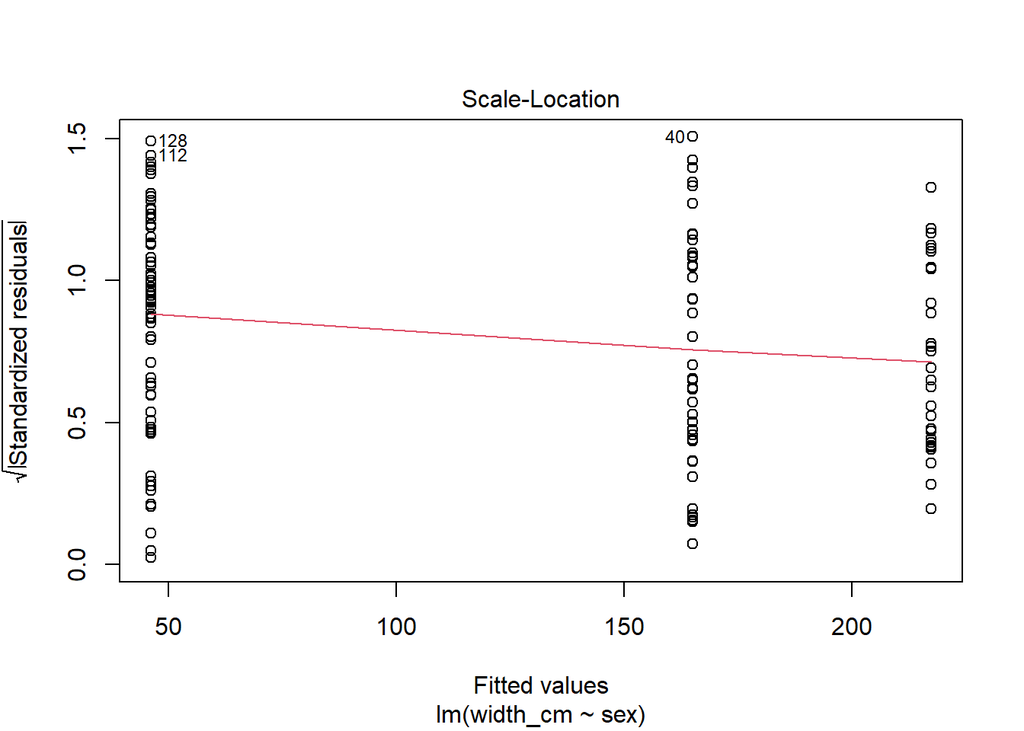

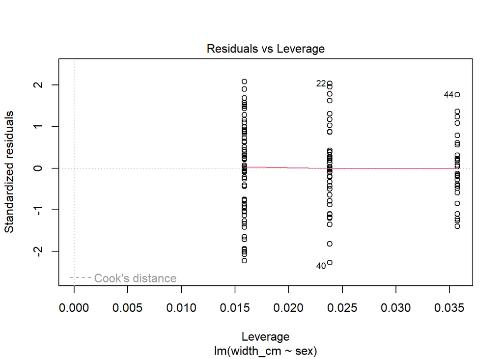

```r
width_model <- lm(width_cm~sex, ray_data)
plot(width_model)
```

Assumptions look ok, so I can check results.

```r
library(car)
Anova(width_model, type="III")
```

```
Anova Table (Type III tests)

Response: width_cm
             Sum Sq  Df F value    Pr(>F)
(Intercept) 1323166   1   44572 < 2.2e-16 ***
sex          693739   2   11685 < 2.2e-16 ***
Residuals      3859 130
---
Signif. codes:  0 '***' 0.001 '**' 0.01 '*' 0.05 '.' 0.1 ' ' 1
```

There is a significant difference among groups (F<sub>2,130</sub>=11,685, p<.001), so I reject the null that all groups are the same. To find which group is different, I can carry out post-hoc tests using the Tukey method to control for family-wise error rate.

```r
library(multcomp)
summary(glht(width_model,linfct = mcp(sex = "Tukey")))
```

```
     Simultaneous Tests for General Linear Hypotheses

Multiple Comparisons of Means: Tukey Contrasts


Fit: lm(formula = width_cm ~ sex, data = ray_data)

Linear Hypotheses:
                      Estimate Std. Error t value Pr(>|t|)
male - female == 0     -52.337      1.329  -39.37   <2e-16 ***
unknown - female == 0 -171.168      1.238 -138.32   <2e-16 ***
unknown - male == 0   -118.831      1.085 -109.48   <2e-16 ***
---
Signif. codes:  0 '***' 0.001 '**' 0.01 '*' 0.05 '.' 0.1 ' ' 1
(Adjusted p values reported -- single-step method)
```

- clear explanation of how results relate to your stated hypotheses (1.5 point)

The results indicate all groups have different average wing widths (all p<.001 for post hoc tests).